# Untitled

2025-10-30

# Predicting off the first Innings

In this section we simply apply what we have learnt in section .1 to a data set which contains the entirety of the first innings and the first 10 overs of the second innings. As the model is now predicting off ~60% of the game being played we hope to see a significant increase in AUC. This would indicate that the model is predicting off the match data and not just the meta data (ie the teams that are playing).

## Data setup

Following a very similar process as to section 1, we set up the data to include all the results from the first innings and the first 10 overs of the second innings.

```r
# ----------------------------
# Load packages
# ----------------------------
library(dplyr)
library(readr)
library(glmnet)
library(caret)
library(pROC)
data <- read_csv("../data/processed/odi_bbb_recent.csv")
#First innings summary
first_innings <- data %>%
  mutate(over = floor(ball)) %>%
  filter(innings == 1) %>%
  mutate(runs = coalesce(runs_off_bat,0) + coalesce(extras,0)) %>%
  group_by(match_id) %>%
  summarise(
    batting_team_1st = first(batting_team),
    bowling_team_1st = first(bowling_team),
    balls_played_1st = n(),
    overs_played_1st = max(over) + 1,
    runs_total_1st = sum(runs, na.rm = TRUE),
    boundaries_1st = sum(runs_off_bat %in% c(4,6), na.rm = TRUE),
    wickets_1st = sum(!is.na(player_dismissed)),
    dot_balls_1st = sum(runs_off_bat == 0, na.rm = TRUE),
    extras_total_1st = sum(coalesce(extras,0), na.rm = TRUE),
    .groups = "drop"
  ) %>%
  mutate(
    run_rate_1st = runs_total_1st / pmax(overs_played_1st, 1/6),
    boundary_rate_1st = boundaries_1st / pmax(balls_played_1st,1),
    dot_ball_rate_1st = dot_balls_1st / pmax(balls_played_1st,1),
    wickets_rate_1st = wickets_1st / pmax(overs_played_1st, 1/6)
  )


# First 10 overs of second innings

second10_overs <- data %>%
  mutate(over = floor(ball)) %>%
  filter(innings == 2, over < 10) %>%
  mutate(runs = coalesce(runs_off_bat,0) + coalesce(extras,0))

second10_summary <- second10_overs %>%
  group_by(match_id) %>%
  summarise(
    batting_team = first(batting_team),
    runs_total_2nd10 = sum(runs, na.rm = TRUE),
    boundaries_2nd10 = sum(runs_off_bat %in% c(4,6), na.rm = TRUE),
    wickets_2nd10 = sum(!is.na(player_dismissed)),
    dot_balls_2nd10 = sum(runs_off_bat == 0, na.rm = TRUE),
    balls_played_2nd10 = n(),
    .groups = "drop"
  ) %>%
  mutate(
    run_rate_2nd10 = runs_total_2nd10 / pmax(balls_played_2nd10 / 6, 1/6),
    boundary_rate_2nd10 = boundaries_2nd10 / pmax(balls_played_2nd10,1),
    dot_ball_rate_2nd10 = dot_balls_2nd10 / pmax(balls_played_2nd10,1),
    wickets_rate_2nd10 = wickets_2nd10 / pmax(balls_played_2nd10 / 6, 1/6)
  )


# Momentum features from second innings first 10 overs

over_summary <- second10_overs %>%
  mutate(over = floor(ball), runs = coalesce(runs_off_bat,0) + coalesce(extras,0)) %>%
  group_by(match_id, over) %>%
  summarise(
    over_runs = sum(runs, na.rm = TRUE),
    over_boundaries = sum(runs_off_bat %in% c(4,6), na.rm = TRUE),
    balls_in_over = n(),
    .groups = "drop"
  )

over_rollups <- over_summary %>%
  group_by(match_id) %>%
  summarise(
    first3_runs = sum(over_runs[over %in% 0:2], na.rm = TRUE),
    last3_runs  = sum(over_runs[over %in% 7:9], na.rm = TRUE),
    first3_boundaries = sum(over_boundaries[over %in% 0:2], na.rm = TRUE),
    last3_boundaries  = sum(over_boundaries[over %in% 7:9], na.rm = TRUE),
    first3_balls = sum(balls_in_over[over %in% 0:2], na.rm = TRUE),
    last3_balls = sum(balls_in_over[over %in% 7:9], na.rm = TRUE),
    .groups = "drop"
  ) %>%
  mutate(
    first3_rr = first3_runs / pmax(first3_balls / 6, 1/6),
    last3_rr  = last3_runs  / pmax(last3_balls / 6, 1/6),
    acceleration = last3_rr - first3_rr,
    boundary_momentum = (last3_boundaries / pmax(last3_balls,1)) - (first3_boundaries / pmax(first3_balls,1))
  )

#Meta data
match_meta <- data %>%
  distinct(match_id, team1, team2, winner, toss_winner, toss_decision) %>%
  group_by(match_id) %>%
  summarise(
    team1 = first(team1),
    team2 = first(team2),
    winner = first(winner),
    toss_winner = first(toss_winner),
    toss_decision = first(toss_decision),
    .groups = "drop"
  )

#Combine into a model
model_df <- first_innings %>%
  left_join(second10_summary, by = "match_id") %>%
  left_join(over_rollups, by = "match_id") %>%
  left_join(match_meta, by = "match_id")

#Final data set
model_df2 <- model_df %>%
  filter(!is.na(winner)) %>%
  mutate(
    # Target: whether batting team in 2nd innings wins
    batting_team_win = ifelse(winner == batting_team, 1L, 0L),
    batting_team_win_toss = as.integer(batting_team == toss_winner),
    batting_team_is_team1 = as.integer(batting_team == team1),
    batting_team = factor(batting_team),
    bowling_team = factor(if_else(batting_team == team1, team2, team1)),
    team1 = factor(team1),
    team2 = factor(team2)
  ) %>%
  select(
    match_id, batting_team, bowling_team, batting_team_win,
    runs_total_1st, boundaries_1st, boundary_rate_1st, wickets_1st, dot_balls_1st, dot_ball_rate_1st, extras_total_1st,
    runs_total_2nd10, boundaries_2nd10, boundary_rate_2nd10, wickets_2nd10, dot_balls_2nd10, dot_ball_rate_2nd10,
    first3_rr, acceleration, boundary_momentum,
    batting_team_win_toss
  )

glimpse(model_df2) #To check it is set up correctly
```

```
## Rows: 1,125
## Columns: 21
## $ match_id              <dbl> 656399, 656401, 656403, 656405, 656407, 656409, …
## $ batting_team          <fct> Sri Lanka, England, Zimbabwe, Pakistan, Ireland,…
## $ bowling_team          <fct> New Zealand, Australia, South Africa, India, Wes…
## $ batting_team_win      <int> 0, 0, 0, 0, 1, 1, 1, 1, 0, 0, 0, 0, 1, 0, 0, 1, …
## $ runs_total_1st        <dbl> 331, 342, 339, 300, 304, 142, 285, 123, 310, 307…
## $ boundaries_1st        <int> 38, 41, 33, 28, 40, 16, 34, 9, 35, 36, 29, 40, 2…
## $ boundary_rate_1st     <dbl> 0.12218650, 0.13531353, 0.10509554, 0.09210526, …
## $ wickets_1st           <int> 6, 9, 4, 7, 7, 10, 7, 10, 7, 7, 8, 2, 9, 1, 5, 1…
## $ dot_balls_1st         <int> 141, 135, 142, 125, 175, 149, 178, 138, 157, 150…
## $ dot_ball_rate_1st     <dbl> 0.4533762, 0.4455446, 0.4522293, 0.4111842, 0.56…
## $ extras_total_1st      <dbl> 13, 5, 19, 6, 10, 6, 26, 13, 23, 10, 21, 24, 17,…
## $ runs_total_2nd10      <dbl> 46, 50, 56, 46, 61, 66, 55, 116, 25, 38, 47, 54,…
## $ boundaries_2nd10      <int> 7, 7, 8, 5, 7, 12, 8, 20, 3, 3, 8, 5, 2, 8, 6, 1…
## $ boundary_rate_2nd10   <dbl> 0.11666667, 0.10937500, 0.12500000, 0.07462687, …
## $ wickets_2nd10         <int> 0, 2, 1, 1, 0, 2, 0, 2, 4, 1, 1, 3, 1, 3, 2, 4, …
## $ dot_balls_2nd10       <int> 38, 43, 46, 48, 39, 38, 43, 33, 49, 44, 40, 39, …
## $ dot_ball_rate_2nd10   <dbl> 0.6333333, 0.6718750, 0.7187500, 0.7164179, 0.62…
## $ first3_rr             <dbl> 4.3333333, 3.0000000, 6.3000000, 3.4736842, 6.63…
## $ acceleration          <dbl> 1.3333333, 0.0000000, 0.7000000, -1.2631579, -1.…
## $ boundary_momentum     <dbl> 0.055555556, 0.005555556, -0.033333333, 0.000000…
## $ batting_team_win_toss <int> 1, 1, 1, 0, 1, 1, 1, 0, 1, 0, 1, 0, 1, 0, 0, 0, …
```

## Fit the model

We have set up the model in a similar way to our logistic model in section 1. That is we are predicting whether the batting team in the second innings wins the game or not. This solves the annoying non-linear relationship problems we had previously.

```r
model_df2$batting_team_win <- as.numeric(model_df2$batting_team_win)

# Split into train/test (80/20)
set.seed(123)
trainIndex <- createDataPartition(model_df2$batting_team_win, p = 0.8, list = FALSE)
train_data2 <- model_df2[trainIndex, ]
test_data2  <- model_df2[-trainIndex, ]

# Fit logistic regression model
# Single logistic regression with interactions
logit_model2 <- glm(
  batting_team_win ~  . - match_id,
  data = train_data2,
  family = binomial
)


summary(logit_model2)
```

```
##
## Call:
## glm(formula = batting_team_win ~ . - match_id, family = binomial,
##     data = train_data2)
##
## Coefficients:
##                                        Estimate Std. Error z value Pr(>|z|)
## (Intercept)                           18.991056   5.361108   3.542 0.000397 ***
## batting_teamBangladesh                -0.723627   0.571001  -1.267 0.205049
## batting_teamCanada                    -4.949299   1.063297  -4.655 3.24e-06 ***
## batting_teamEngland                    0.520675   0.511864   1.017 0.309051
## batting_teamHong Kong                 -6.418434   1.589218  -4.039 5.37e-05 ***
## batting_teamIndia                     -0.148497   0.493377  -0.301 0.763429
## batting_teamIreland                   -1.649746   0.680216  -2.425 0.015295 *
## batting_teamJersey                   -16.992881 573.495072  -0.030 0.976362
## batting_teamNamibia                   -3.643744   0.944156  -3.859 0.000114 ***
## batting_teamNepal                     -3.262054   0.905155  -3.604 0.000314 ***
## batting_teamNetherlands               -3.891381   0.955803  -4.071 4.67e-05 ***
## batting_teamNew Zealand                0.081749   0.493204   0.166 0.868353
## batting_teamOman                      -3.823294   0.899088  -4.252 2.11e-05 ***
## batting_teamPakistan                  -0.062080   0.506346  -0.123 0.902421
## batting_teamPapua New Guinea          -5.209088   1.057315  -4.927 8.36e-07 ***
## batting_teamScotland                  -2.424386   0.810452  -2.991 0.002777 **
## batting_teamSouth Africa              -1.204514   0.510688  -2.359 0.018343 *
## batting_teamSri Lanka                 -0.926065   0.572846  -1.617 0.105964
## batting_teamUnited Arab Emirates      -4.209661   0.944821  -4.456 8.37e-06 ***
## batting_teamUnited States of America  -3.997561   0.959111  -4.168 3.07e-05 ***
## batting_teamWest Indies               -0.732629   0.548814  -1.335 0.181899
## batting_teamZimbabwe                  -1.565104   0.688149  -2.274 0.022944 *
## bowling_teamBangladesh                 0.111299   0.502373   0.222 0.824666
## bowling_teamCanada                     3.923304   1.184590   3.312 0.000926 ***
## bowling_teamEngland                    1.068443   0.469074   2.278 0.022740 *
## bowling_teamHong Kong                  3.502222   4.167693   0.840 0.400726
## bowling_teamIndia                     -0.295076   0.505718  -0.583 0.559571
## bowling_teamIreland                    1.968928   0.770899   2.554 0.010647 *
## bowling_teamJersey                    16.848834 882.743924   0.019 0.984772
## bowling_teamNamibia                    2.784963   0.918051   3.034 0.002417 **
## bowling_teamNepal                      3.267419   0.985083   3.317 0.000910 ***
## bowling_teamNetherlands                0.428998   0.780077   0.550 0.582359
## bowling_teamNew Zealand                0.374333   0.520471   0.719 0.472005
```

[output cut: 22 more lines]

```
## dot_ball_rate_2nd10                  -11.479336  12.650455  -0.907 0.364182
## first3_rr                             -0.039255   0.113603  -0.346 0.729683
## acceleration                          -0.055890   0.094621  -0.591 0.554739
## boundary_momentum                      1.358037   2.024249   0.671 0.502294
## batting_team_win_toss                 -0.067343   0.212564  -0.317 0.751385
## ---
## Signif. codes:  0 '***' 0.001 '**' 0.01 '*' 0.05 '.' 0.1 ' ' 1
##
## (Dispersion parameter for binomial family taken to be 1)
##
##     Null deviance: 1244.66  on 899  degrees of freedom
## Residual deviance:  680.33  on 840  degrees of freedom
## AIC: 800.33
##
## Number of Fisher Scoring iterations: 13
```

The summary tells us some interesting things. Wickets in the second over are again a negative thing (decrease log odds) for our batting team, which is good. However, wickets in the first effect, whilst positive which is good, are a much smaller effect. This is likely because it is more important to know the number of runs that were scored in the first innings and if the run rate is high enough to reach it. Again we have a number of predictors with low significance which suggests that regularisation would again be a good idea. First, however, lets see if the model has a higher AUC already.

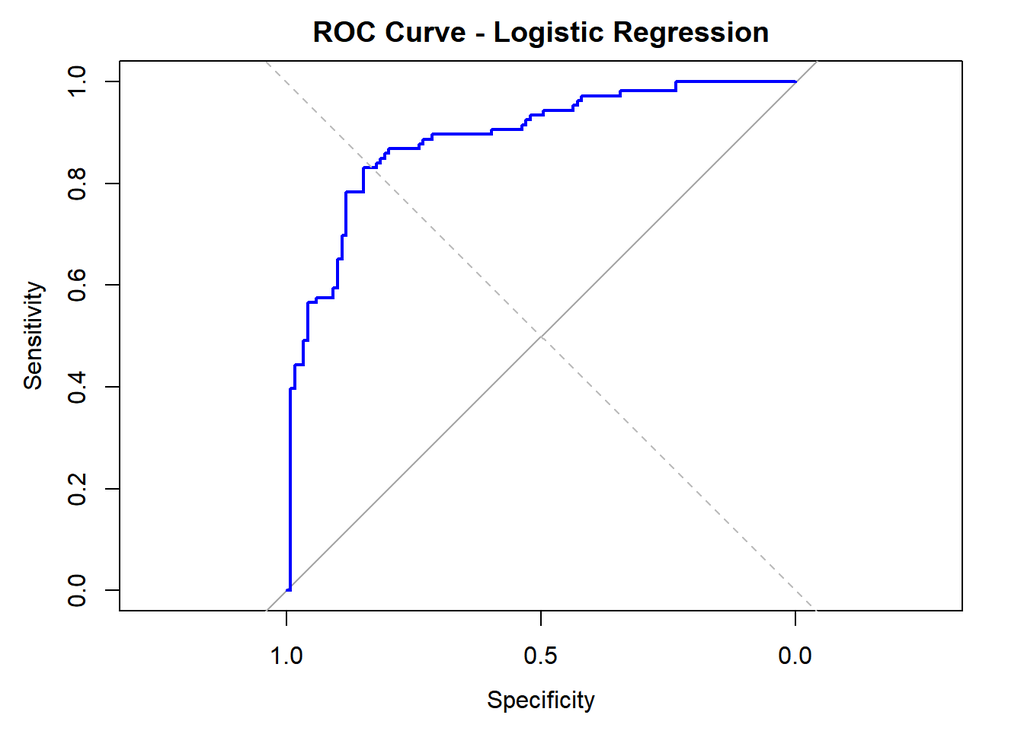

```r
# Predict probabilities on test set
logistic_model2_pred <- predict(logit_model2, newdata = test_data2, type = "response")

# Convert to class predictions (threshold = 0.5)
pred_classes <- ifelse(logistic_model2_pred > 0.5, 1, 0)


# ROC curve and AUC
roc_logistic2 <- roc(test_data2$batting_team_win, logistic_model2_pred)
# Plot ROC curve
plot(roc_logistic2, col = "blue", lwd = 2, main = "ROC Curve - Logistic Regression")
abline(a = 0, b = 1, lty = 2, col = "gray")
```

```r
# AUC value
auc_value <- auc(roc_logistic2)
print(paste("AUC =", round(auc_value, 3)))
```

```
## [1] "AUC = 0.887"
```

Good, we have already seen a significant increase in AUC, indicating that our model is better at discriminating between the two outcomes. Now, lets see if regularisation improves our model performance further.

```r
# Prepare data - for GLM net we need matrices
x_train2 <- model.matrix(batting_team_win ~ . - match_id, data = train_data2)[, -1]  # remove intercept
y_train2 <- train_data2$batting_team_win

x_test2 <- model.matrix(batting_team_win ~ . - match_id, data = test_data2)[, -1]  # remove intercept
y_test2 <- test_data2$batting_team_win

# Grid of alpha values to try
alpha_grid <- seq(0, 1, by = 0.05)  # from Ridge (0) to LASSO (1)
lambda_seq <- 10^seq(-6, 2, length = 200) #Sometime you need to check optimal lambda is in this sequence (I have done separately)

# Store CV results
cv_results <- list()
cv_auc <- numeric(length(alpha_grid))

set.seed(123)
for (i in seq_along(alpha_grid)) {
  cv <- cv.glmnet(
    x_train2, y_train2,
    alpha = alpha_grid[i],
    lambda = lambda_seq,
    family = "binomial",
    type.measure = "auc",
    nfolds = 10
  )
  cv_results[[i]] <- cv
  cv_auc[i] <- max(cv$cvm)  # best AUC for this alpha
}

# Find alpha with best CV AUC
best_alpha <- alpha_grid[which.max(cv_auc)]
best_lambda <- cv_results[[which.max(cv_auc)]]$lambda.min

cat("Best alpha:", best_alpha, "\n")
```

```
## Best alpha: 1
```

```r
cat("Best lambda:", best_lambda, "\n")
```

```
## Best lambda: 0.01516717
```

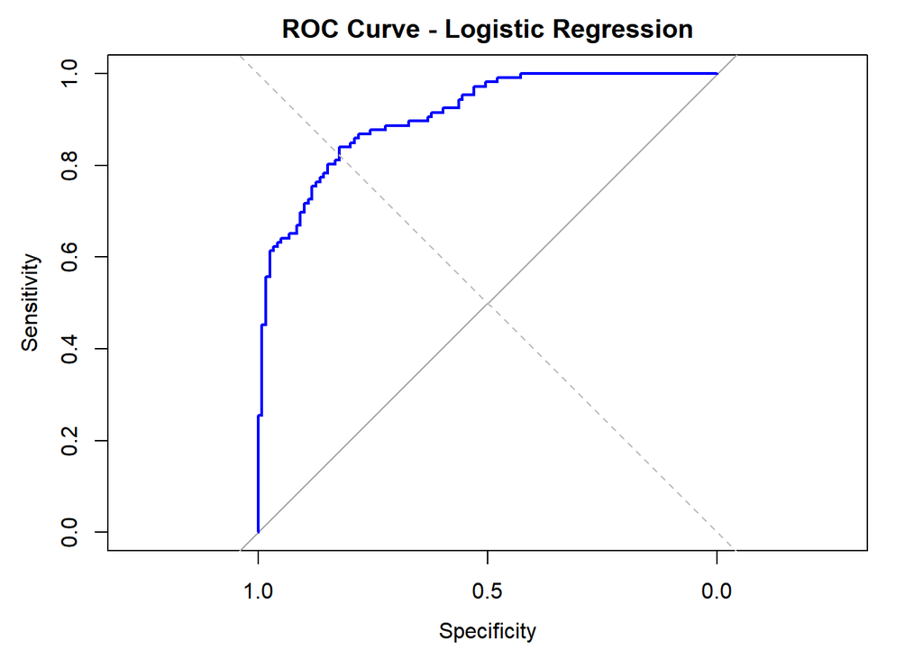

```r
# Refit final elastic net model on full training set
final_model <- glmnet(
  x_train2, y_train2,
  alpha = best_alpha,
  lambda = best_lambda,
  family = "binomial"
)

# Predict probabilities on test set
final_model_pred <- predict(final_model, newx = x_test2, type = "response")

# Convert to class predictions (threshold = 0.5)
pred_classes <- ifelse(final_model_pred > 0.5, 1, 0)


# ROC curve and AUC
roc_final <- roc(y_test2, final_model_pred)
# Plot ROC curve
plot(roc_final, xlim=c(1,0),col = "blue", lwd = 2, main = "ROC Curve - Logistic Regression")
abline(a = 0, b = 1, lty = 2, col = "gray")
```

```r
# AUC value
auc_value <- auc(roc_final)
print(paste("AUC =", round(auc_value, 3)))
```

```
## [1] "AUC = 0.909"
```

Again our AUC has improved. An AUC of over 0.9 shows that at this point in the game the model is very confident in predicting the outcome of the game. This would make it a much more usable model in the real world especially as it is so fast to run.